# HW 1: OLS Review

Advanced Regression (STAT 353-0)

Author

Chan Lee

Published

January 18, 2025

**Github Repo Link**

To link to your github **repo**sitory, appropriately edit the example link below. Meaning replace `https://your-github-repo-url` with your github repo url. Suggest verifying the link works before submitting.

stat-353-0-2025-winter/stat-353-0-2025-winter-hw-1-ols-review-HW1-ols-review

## Overview

In this homework, you will review OLS regression. The concepts focused on here are obviously not all of what you know (from STAT 350), but they are concepts that are particularly important for this course. Pay particular attention to interpretation.

## Data

For this assignment, we are using the `Duncan` dataset. This dataset provides data on the prestige and other characteristics of 45 U. S. occupations in 1950. The data was collected by the sociologist [Otis Dudley Duncan](https://en.wikipedia.org/wiki/Otis_Dudley_Duncan).

## Preliminaries

As a first step, we load the `{car}` package. This is the package developed by the author of our textbook and contains several useful functions and datasets, so we will be using it throughout this quarter.

Begin by examining the first few rows of the `Duncan` data:

```r
library("car") # load car and carData packages

head(Duncan, n=10)
```

```
           type income education prestige
accountant prof     62        86       82
pilot      prof     72        76       83
architect  prof     75        92       90
author     prof     55        90       76
chemist    prof     64        86       90
minister   prof     21        84       87
professor  prof     64        93       93
dentist    prof     80       100       90
reporter     wc     67        87       52
engineer   prof     72        86       88
```

```r
dim(Duncan)
```

```
[1] 45  4
```

Obtain summary statistics for the variables in `Duncan`:

```r
summary(Duncan)
```

```
   type        income        education         prestige
 bc  :21   Min.   : 7.00   Min.   :  7.00   Min.   : 3.00
 prof:18   1st Qu.:21.00   1st Qu.: 26.00   1st Qu.:16.00
 wc  : 6   Median :42.00   Median : 45.00   Median :41.00
           Mean   :41.87   Mean   : 52.56   Mean   :47.69
           3rd Qu.:64.00   3rd Qu.: 84.00   3rd Qu.:81.00
           Max.   :81.00   Max.   :100.00   Max.   :97.00
```

As a first graph, we view a histogram of the variable `prestige`:

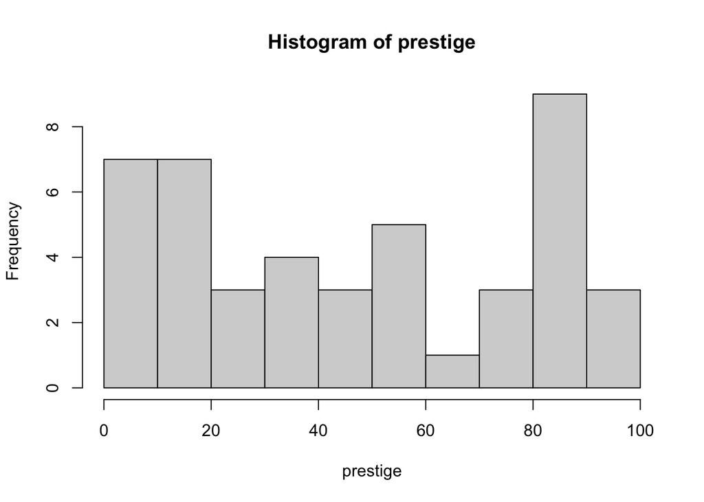

```r
with(Duncan, hist(prestige))
```

## Exercises

### 1. Examining the Data

A first step for any analysis should include Exploratory Data Analysis (EDA). This allows you to check to see that you understand the variables - how they are coded, if they are factors or continuous, and if there are mistakes.

The `scatterplotMatrix()` function in the **car** package produces scatterplots for all pairs of variables. A few relatively remote points are marked by case names, in this instance by occupation.

**Solution**

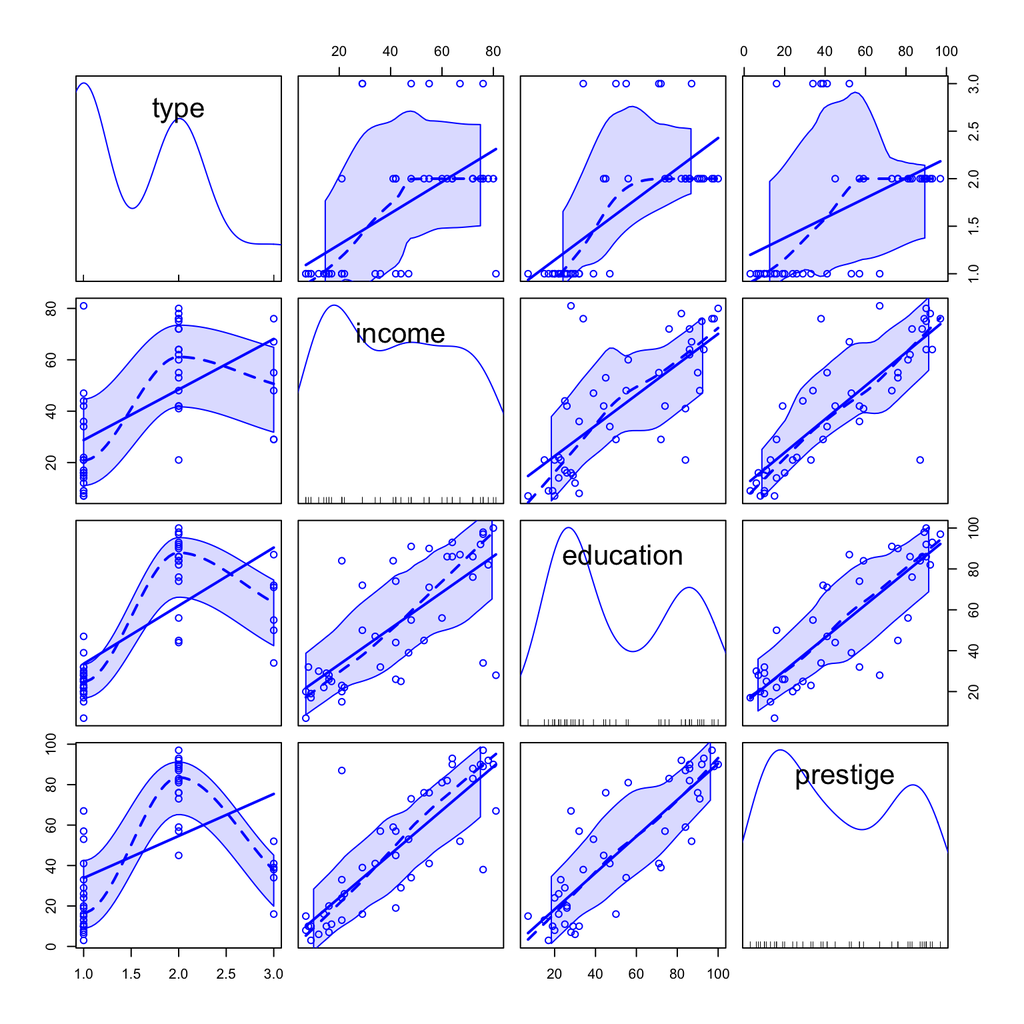

```r
scatterplotMatrix(Duncan)
```

Via the scatterplots above - and any other EDA you’d like to do - describe the data. What seems to be going on here?

**Solution**

### 2. Regression Analysis

#### A. Model 1

Use the`lm()` function to fit a linear regression model to the data, in which `education` and `income` are regressed on `prestige`.

Interpret the findings from this model. Are education and income good explanations for an occupation’s prestige? Interpret the coefficient for income - what does it mean? Does education or income have a larger effect on prestige? Justify your conclusion.

**Solution**

We see from the summary statistics of the regression model below, that education and income are both good predictors (but not necessarily good explanations, since explanation implies causality) of prestige, since the respective p values are extremely small (<0.001). Furthermore, we see that the multiple R squared value is very high (0.8282), which means that education and income are indeed good predictors together, of prestige. The coefficient for income, 0.59873, signifies the chance in prestige levels that accompanies an additional percentage point of occupational incumbents who make $3,500 or more in 1950. Since income has a slightly higher coefficient of 0.59873 compared to that for education, which is 0.54583, income has a slightly larger effect on prestige.

```r
# Fit the linear regression model
model1 <- lm(prestige ~ education + income, data = Duncan)

# Display the summary of the model
summary(model1)
```

```
Call:
lm(formula = prestige ~ education + income, data = Duncan)

Residuals:
    Min      1Q  Median      3Q     Max
-29.538  -6.417   0.655   6.605  34.641

Coefficients:
            Estimate Std. Error t value Pr(>|t|)
(Intercept) -6.06466    4.27194  -1.420    0.163
education    0.54583    0.09825   5.555 1.73e-06 ***
income       0.59873    0.11967   5.003 1.05e-05 ***
---
Signif. codes:  0 '***' 0.001 '**' 0.01 '*' 0.05 '.' 0.1 ' ' 1

Residual standard error: 13.37 on 42 degrees of freedom
Multiple R-squared:  0.8282,    Adjusted R-squared:   0.82
F-statistic: 101.2 on 2 and 42 DF,  p-value: < 2.2e-16
```

#### B. Model 2

Now, add in the `type` of occupation to the model. Is the model with `type` a better model? Explain what statistics you would use to make this decision, conduct the analysis, and interpret the results.

**Solution**

There are several statistics that can help determine whether adding type would produce a better model for predicting prestige. Firstly, we can compare the adjusted R^2 values of the two models. We find that model 1’s adjusted R^2 value is 0.82 while that of model 2 is 0.9, which reveals that adding type increases the model’s ability to explain variance in prestige, making it an improvement. Furthermore, we can do an ANOVA test. We find that the ANOVA test gives a p value of <0.001, meaning that adding type significantly improves the model.

```r
# Updated model with `type`
model2 <- lm(prestige ~ education + income + type, data = Duncan)
summary(model2)
```

```
Call:
lm(formula = prestige ~ education + income + type, data = Duncan)

Residuals:
    Min      1Q  Median      3Q     Max
-14.890  -5.740  -1.754   5.442  28.972

Coefficients:
             Estimate Std. Error t value Pr(>|t|)
(Intercept)  -0.18503    3.71377  -0.050  0.96051
education     0.34532    0.11361   3.040  0.00416 **
income        0.59755    0.08936   6.687 5.12e-08 ***
typeprof     16.65751    6.99301   2.382  0.02206 *
typewc      -14.66113    6.10877  -2.400  0.02114 *
---
Signif. codes:  0 '***' 0.001 '**' 0.01 '*' 0.05 '.' 0.1 ' ' 1

Residual standard error: 9.744 on 40 degrees of freedom
Multiple R-squared:  0.9131,    Adjusted R-squared:  0.9044
F-statistic:   105 on 4 and 40 DF,  p-value: < 2.2e-16
```

```r
# compare adjusted R^2 values
summary(model1)$adj.r.squared
```

```
[1] 0.8199912
```

```r
summary(model2)$adj.r.squared
```

```
[1] 0.9043723
```

```r
anova(model1, model2)
```

```
Analysis of Variance Table

Model 1: prestige ~ education + income
Model 2: prestige ~ education + income + type
  Res.Df    RSS Df Sum of Sq     F    Pr(>F)
1     42 7506.7
2     40 3798.0  2    3708.7 19.53 1.208e-06 ***
---
Signif. codes:  0 '***' 0.001 '**' 0.01 '*' 0.05 '.' 0.1 ' ' 1
```

### 3. Regression Diagnostics

#### A. Non-normality

The `rstudent()` function returns studentized residuals, and the `densityPlot()` function fits an adaptive kernel density estimator to the distribution of the studentized residuals. A `qqPlot()` can be used as a check for nonnormal errors, comparing the studentized residuals to a t-distribution.

Use these to examine the results of your best model from Question 2. What do you conclude?

**Solution**

We can see from the density and QQ plot that the the residuals are slightly right-skewed, but mostly follow the normal distribution shape. This shows that the best model from Question 2 does not violate the normality condition for the residuals.

```r
# Extract studentized residuals
studentized_residuals <- rstudent(model2)

# View a summary of studentized residuals
summary(studentized_residuals)
```

```
    Min.  1st Qu.   Median     Mean  3rd Qu.     Max.
-1.62076 -0.61014 -0.18395  0.02461  0.56783  3.82940
```

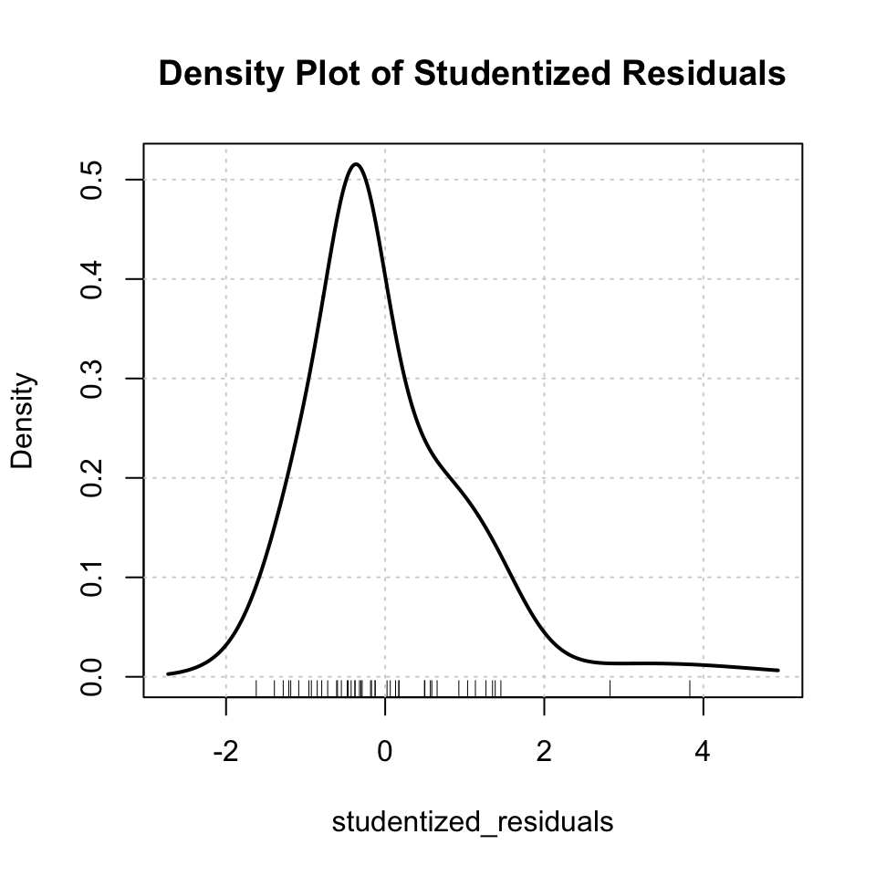

```r
# Density plot of studentized residuals
densityPlot(studentized_residuals, main = "Density Plot of Studentized Residuals")
```

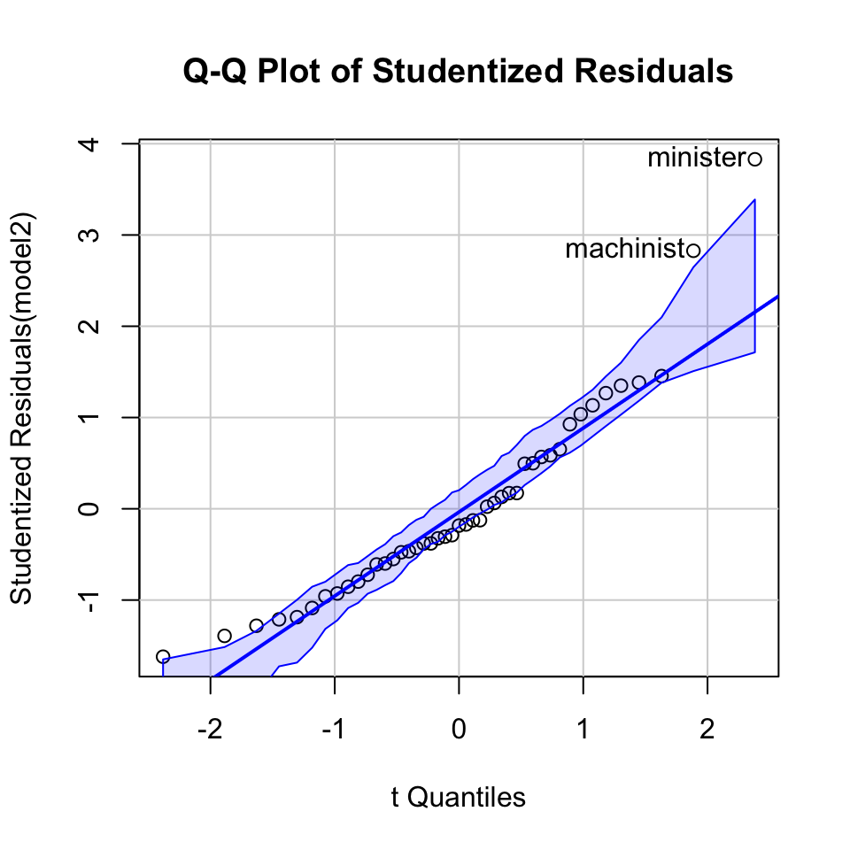

```
 minister machinist
        6        28
```

```r
# Q-Q plot of studentized residuals
qqPlot(model2, main = "Q-Q Plot of Studentized Residuals")
```

#### B. Influence = outliers * leverage

The `outlierTest()` function tests for outliers in the regression. The `influenceIndexPlot()` function creates a graph that displays influence measures in index plots. The `avPlots()` function creates added variable plots, which allow you to visualize how influential data points might be affecting (or not) the estimated coefficients.

Using these (and/or other tools), using your preferred model from Question 2, are there any influential data points?

If the diagnostics suggest that there are influential points, does removing these influential points change the results of the analysis? Compare models using the `compareCoefs()` function. What do you conclude?

**Solution**

From the tests, I observed pretty consistently that minister and machinist were two glaring outliers in the data. There were other “milder” outlier occupations, such as contractor and RR engineer.

Removing the outliers, “minister” and “machinist,” from the model led to noticeable changes in the regression coefficients and their precision. The intercept shifted slightly, with a reduction in its standard error, though it remains less meaningful as a predictor. The coefficient for education decreased from 0.3453 to 0.2775, indicating that the outliers had an upward influence on its estimated effect. Additionally, the standard error for education reduced, reflecting increased precision. In contrast, the income coefficient increased from 0.5975 to 0.6943, suggesting that the outliers dampened its apparent impact on prestige. The standard error for income also decreased, further improving confidence in the estimate. For the categorical variable type, the coefficients remained similar, but their standard errors reduced, indicating more stable estimates after removing the outliers. Overall, removing the influential data points resulted in a model with more precise and reliable estimates, suggesting that “minister” and “machinist” were exerting undue influence on the original model’s results.

```r
outlierTest(model2)
```

```
         rstudent unadjusted p-value Bonferroni p
minister 3.829396         0.00045443      0.02045
```

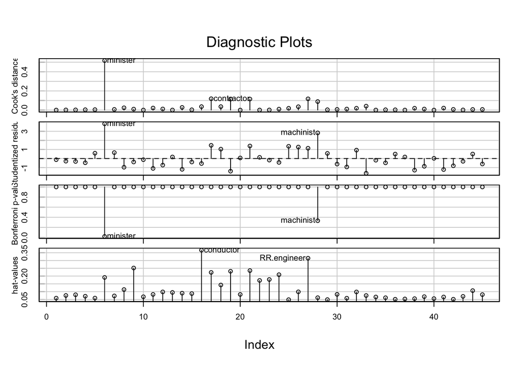

```r
influenceIndexPlot(model2)
```

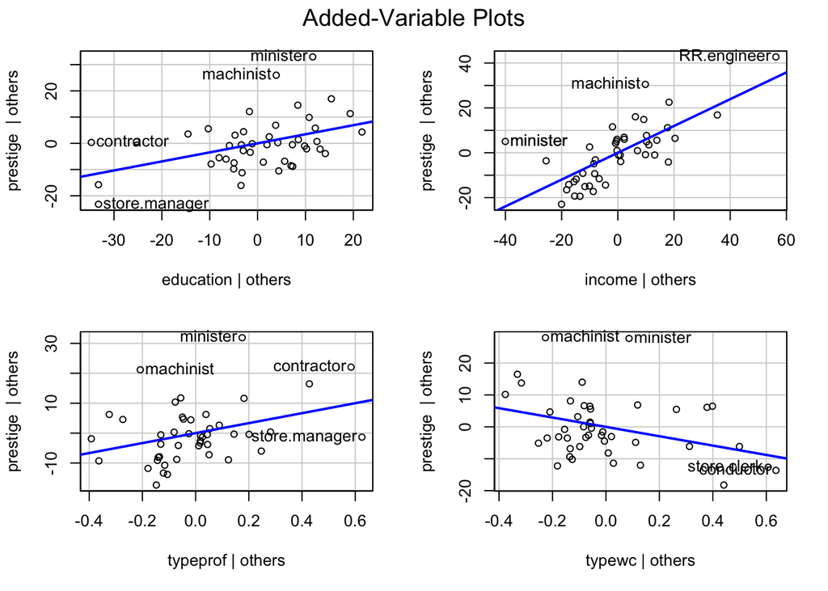

```r
avPlots(model2)
```

```r
# Remove the outlier occupations
duncan_no_outliers <- Duncan[!rownames(Duncan) %in% c("minister", "machinist"), ]

# Refit the model without outliers
model_no_outliers <- lm(prestige ~ education + income + type, data = duncan_no_outliers)

# Compare coefficients between the two models
compareCoefs(model2, model_no_outliers)
```

```
Calls:
1: lm(formula = prestige ~ education + income + type, data = Duncan)
2: lm(formula = prestige ~ education + income + type, data =
  duncan_no_outliers)

            Model 1 Model 2
(Intercept)  -0.185  -1.959
SE            3.714   2.902

education    0.3453  0.2775
SE           0.1136  0.0892

income       0.5975  0.6943
SE           0.0894  0.0752

typeprof      16.66   16.21
SE             6.99    5.54

typewc       -14.66  -13.61
SE             6.11    4.80
```

#### C. Non-linearity

Component-plus-residual plots allow for the detection of non-linearity in the partial relationship between each covariate and the outcome. These can be created using the `crPlots()` function.

For your preferred model, does it appear there is any nonlinearity? Explain.

**Solution**

Based on the crPlots for education vs prestige and income vs prestige, we can see that the partial relationship between these two covariates and prestige are fairly linear. The third covariate, type, is a categorical variable, and as such, linearity does not directly apply. However, it is evident that the different occupational categories exert distinct influences on prestige.

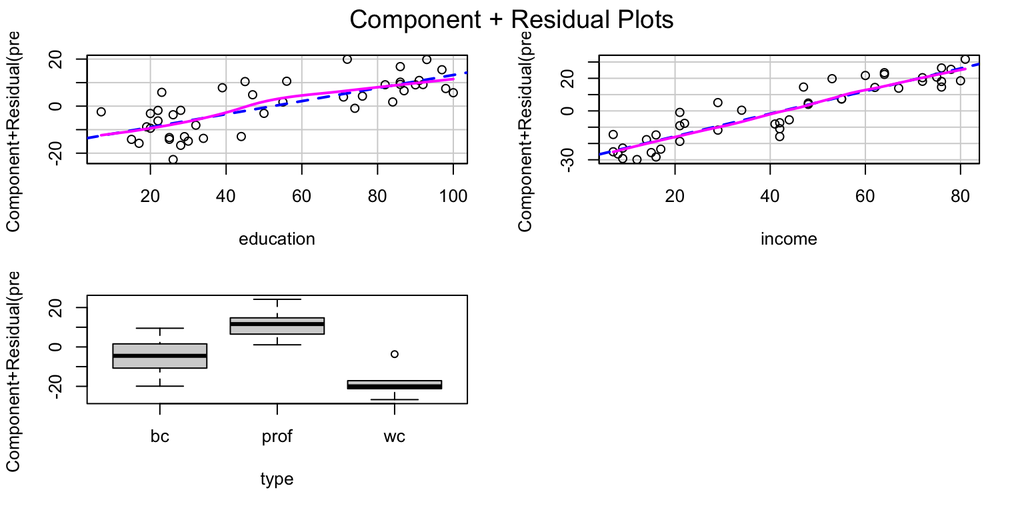

```r
crPlots(model_no_outliers)
```

#### D. Heteroscedasticity

Non-constant error variance can be tested using the `ncvTest()` function.

Does it appear that this is a concern with this data? Explain

**Solution**

Because we get a high p value of 0.3534 and a low chi-squared value of 0.86 from our test, we conclude that the assumption of homoscedasticity has not been violated.

```r
ncvTest(model_no_outliers)
```

```
Non-constant Variance Score Test
Variance formula: ~ fitted.values
Chisquare = 0.8612201, Df = 1, p = 0.3534
```

### 4. Interpretation

Should the model above be used to answer a descriptive, explanatory, or predictive question? Explain your answer.

**Solution**

The model above should be used to answer a descriptive question, as it displays the association between several covariates and a response variable. There is not enough information to corroborate the existence of causation between any of the predictors and prestige. The model could also potentially be used to answer a predictive question, such as if some new occupation were to be assessed, how the associated education level, income level, and occupation type could predict the prestige of the job, using our mdoel.